# results and discussion outline

## Supplementary Info

#### Sensitivity Analysis results

There were two metrics used to look at Sobol indices in the sensitivity analysis. The first was the average LAI in 2011, as the pre-drought conditions. The second was the resilience of LAI, or the ratio of the average LAI in 2017 to the average LAI in 2011.

The parameter ranges for the sensitivity analysis differed between evergreen and deciduous tree types, as the limits set on some of the parameters varied enough to do two separate analysis.  
For both metrics and tree types, we looked at the parameters with the highest total rank indices. The top 5 for each group are shown in the tables below.

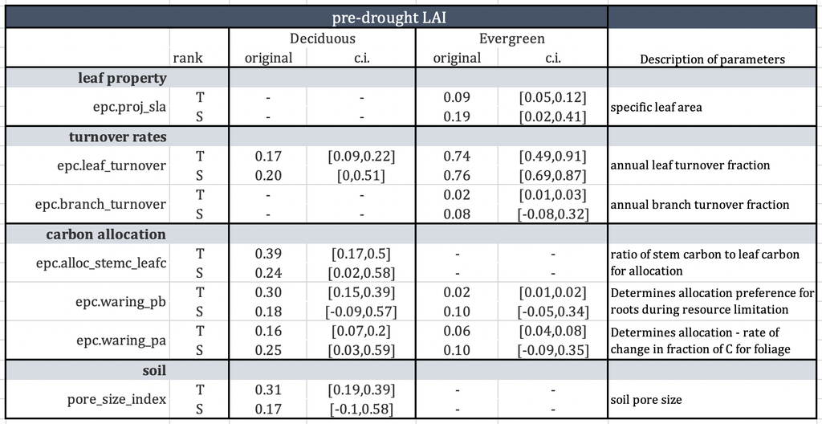

For the 2011 LAI, evergreen parameters that had the largest sensitivity included leaf and branch turnover rates (epc.leaf_turnover, epc.branch_turnover), specific leaf area (epc.proj_sla), and two waring parameters (epc.waring_pa, epc.waring_pb), which are parameters within RHESSys that affect carbon allocation to leaves and roots, based on the allocation strategy from Landsberg and Waring, 1997.

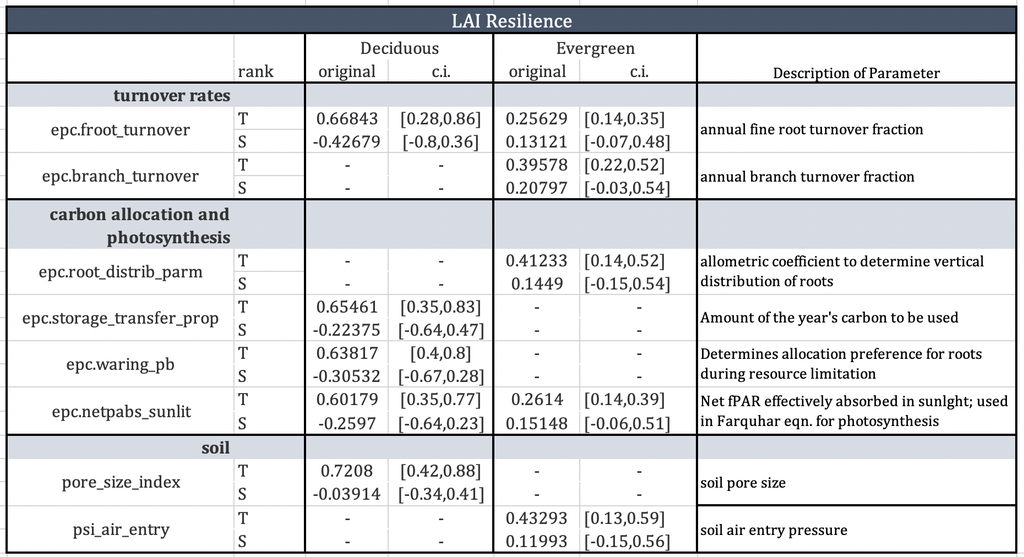

Table of LAI resilience Sobol index results

Both soil parameters were important for resilience, although the level of importance varied. For broadleaf, resilience was more sensitive to soil air entry pressure (psi_air_entry), and for deciduous it was more sensitive to the pore size index, similar to the actual pre-drought LAI.

Both soil parameters affect the field capacity, so the LAI and LAI resilience are sensitive to the overall field capacity in the model. Field capacity determines how much water is available to the tree.

**re-do tables to include all the values for both decid and evg. and each parameter, but bold the ones that were higher or stand out more, rather than blank spots**